# INN_ABRAHAMTHOMAS_Notebook_Full_code_Final

# Summary from EDA:

## From Univariate:

- CreditScore - Median 650. left skewed with outliers on the left, with 300 people having high credit score. Balanced (mean and median close)
- Age - Median 37. Right skewed with outliers on the right. Balanced (mean and median close). Older people seem to exit.
- Tenure: almost balanced except for 0 and 10 years.
- Balance: right skewed. Median close to 100k. 75% close to 125k,
- NumOfProducts: Most have 1 (5k) , and 2 (4.5k)
- HasCrCard: 70% have
- EstimatedSalary: Median: 100k. Median and mean are same.

Note: No outliers unless specifically mentioned above.

## From Bivariate:

- No really high correlation between numerical. 30% positive correlation between Age and Exited. 30% negative correlation between NumofProducts and Balance.
- From Pairplot:
  - CreditScore, Tenure, does not impact
  - Higher Balance, NumOfProducts seem to exit
  - People not having Cards seem to have higher balance
  - 2 NumOfProducts seem to be held even at old age
- Max percentage exited are from Germany - twice more than either Spain or France
- Percentage of Females exiting is more
- Percentage of Nonmembers exiting is more than members
- Median age at exit is 45. Lot of outliers on the right.
- 75% of exiting are at tenure 8

## Data Preprocessing, Dummies, Normalisation

```python
## Separating Independent and Dependent Columns
X = Data.drop(['Exited'],axis=1)
Y = Data['Exited']
```

```python
# Encoding the categorical variables using one-hot encoding - DUMMY VARIABLE CREATION
X = pd.get_dummies(
    X,
    columns=["Geography","Gender"],
    drop_first=True,
)
```

```python
#Data Normalisation - Standardizing some of the numerical variables to zero mean and unit variance.
transformer = StandardScaler()
X[["CreditScore","Tenure","Balance", "EstimatedSalary"]] = transformer.fit_transform(X[["CreditScore","Tenure","Balance", "EstimatedSalary"]])
```

### Train-validation-test Split

```python
# Splitting the dataset into the Training and Test set.
X_train, X_test, y_train, y_test = train_test_split(X,Y, test_size = 0.2, random_state = 42,stratify = Y)
```

```python
# Splitting the Train dataset into the Training and Validation set.
X_train, X_valid, y_train, y_valid = train_test_split(X_train,y_train, test_size = 0.2, random_state = 42,stratify = y_train)
```

```python
#Printing the shapes.
print(X_train.shape,y_train.shape)
print(X_valid.shape,y_valid.shape)
print(X_test.shape,y_test.shape)
```

```
(6400, 11) (6400,)
(1600, 11) (1600,)
(2000, 11) (2000,)
```

```python
#Utility functions

def plot(history, name):
    """
    Function to plot loss/accuracy

    history: an object which stores the metrics and losses.
    name: can be one of Loss or Accuracy
    """
    fig, ax = plt.subplots() #Creating a subplot with figure and axes.
    plt.plot(history.history[name]) #Plotting the train accuracy or train loss
    plt.plot(history.history['val_'+name]) #Plotting the validation accuracy or validation loss

    plt.title('Model ' + name.capitalize()) #Defining the title of the plot.
    plt.ylabel(name.capitalize()) #Capitalizing the first letter.
    plt.xlabel('Epoch') #Defining the label for the x-axis.
    fig.legend(['Train', 'Validation'], loc="outside right upper") #Defining the legend, loc controls the position of the legend.
# defining a function to compute different metrics to check performance of a classification model built using statsmodels

def model_performance_classification(
    model, predictors, target, threshold=0.5
):
    """
    Function to compute different metrics to check classification model performance

    model: classifier
    predictors: independent variables
    target: dependent variable
    threshold: threshold for classifying the observation as class 1
    """

    # checking which probabilities are greater than threshold
    pred = model.predict(predictors) > threshold
    # pred_temp = model.predict(predictors) > threshold
    # # rounding off the above values to get classes
    # pred = np.round(pred_temp)

    acc = accuracy_score(target, pred)  # to compute Accuracy
    recall = recall_score(target, pred, average='weighted')  # to compute Recall
    precision = precision_score(target, pred, average='weighted')  # to compute Precision
    f1 = f1_score(target, pred, average='weighted')  # to compute F1-score

    # creating a dataframe of metrics
    df_perf = pd.DataFrame(
        {"Accuracy": acc, "Recall": recall, "Precision": precision, "F1 Score": f1},
        index=[0],
    )

    return df_perf


def make_confusion_matrix(actual_targets, predicted_targets):
    """
    To plot the confusion_matrix with percentages

    actual_targets: actual target (dependent) variable values
    predicted_targets: predicted target (dependent) variable values
    """
    cm = confusion_matrix(actual_targets, predicted_targets)
    labels = np.asarray(
        [
            ["{0:0.0f}".format(item) + "\n{0:.2%}".format(item / cm.flatten().sum())]
            for item in cm.flatten()
        ]
    ).reshape(cm.shape[0], cm.shape[1])

    plt.figure(figsize=(6, 4))
    sns.heatmap(cm, annot=labels, fmt="")
    plt.ylabel("True label")
    plt.xlabel("Predicted label")
```

## Model Building

```python
# Calculate class weights for imbalanced dataset
cw = (y_train.shape[0]) / np.bincount(y_train)

# Create a dictionary mapping class indices to their respective class weights
cw_dict = {}
for i in range(cw.shape[0]):
    cw_dict[i] = cw[i]

cw_dict
```

```
{0: 1.2558869701726845, 1: 4.9079754601226995}
```

```python
# defining the batch size and # epochs upfront as we'll be using the same values for all models
epochs = 100
batch_size = 64
```

### Model Evaluation Criterion

Following are the possibilities :

1. Predict a customer is exiting but in really, they are NOT exiting
2. Predicting a customer is NOT exiting but customer is exiting

2nd case is more important and can cause loss to bank. ie, reduce False Negatives and maximise True Positives.

**Hence, Recall to be maximised.**

```python
#train_metric_df = pd.DataFrame(columns=["recall"])
#valid_metric_df = pd.DataFrame(columns=["recall"])
```

### Neural Network with SGD Optimizer

```python
# clears the current Keras session, resetting all layers and models previously created, freeing up memory and resources.
tf.keras.backend.clear_session()
# apply a seed so as to reproduce results
np.random.seed(1)
random.seed(1)
tf.random.set_seed(1)
#Initializing the neural network
model0 = Sequential()
#input later
model0.add(Dense(64,activation="relu",input_dim=X_train.shape[1]))
# 1 hidden layer
model0.add(Dense(32,activation="relu"))
# output layer
model0.add(Dense(1,activation="sigmoid"))

model0.summary()
```

```
Model: "sequential"
_________________________________________________________________
 Layer (type)                Output Shape              Param #
=================================================================
 dense (Dense)               (None, 64)                768

 dense_1 (Dense)             (None, 32)                2080

 dense_2 (Dense)             (None, 1)                 33

=================================================================
Total params: 2881 (11.25 KB)
Trainable params: 2881 (11.25 KB)
Non-trainable params: 0 (0.00 Byte)
_________________________________________________________________
```

```python
X_train.info()
```

```
<class 'pandas.core.frame.DataFrame'>
Index: 6400 entries, 3006 to 1558
Data columns (total 11 columns):
 #   Column             Non-Null Count  Dtype
---  ------             --------------  -----
 0   CreditScore        6400 non-null   float64
 1   Age                6400 non-null   int64
 2   Tenure             6400 non-null   float64
 3   Balance            6400 non-null   float64
 4   NumOfProducts      6400 non-null   int64
 5   HasCrCard          6400 non-null   int64
 6   IsActiveMember     6400 non-null   int64
 7   EstimatedSalary    6400 non-null   float64
 8   Geography_Germany  6400 non-null   bool
 9   Geography_Spain    6400 non-null   bool
 10  Gender_Male        6400 non-null   bool
dtypes: bool(3), float64(4), int64(4)
memory usage: 468.8 KB
```

```
Time taken in seconds  32.36002969741821
```

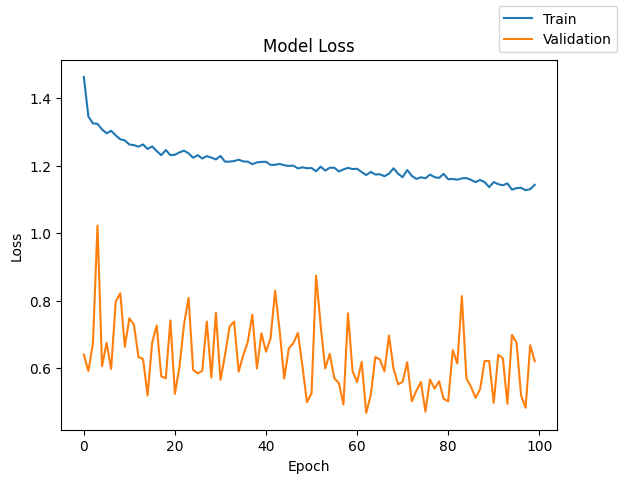

```python
from sklearn.metrics import f1_score
#Fixing the seed for random number generators so that we can ensure we receive the same output everytime
np.random.seed(1)
tf.random.set_seed(1)

optimizer = tf.keras.optimizers.SGD()    # defining SGD as the optimizer to be used
model0.compile(loss='binary_crossentropy', optimizer=optimizer, metrics=[AUC(curve='ROC'), Recall()])
X_train = np.asarray(X_train).astype(np.float32)
y_train = np.asarray(y_train).astype(np.float32)
X_valid = np.asarray(X_valid).astype(np.float32)
y_valid = np.asarray(y_valid).astype(np.float32)
start = time.time()
history0 = model0.fit(X_train, y_train, validation_data=(X_valid,y_valid) , batch_size=batch_size, epochs=epochs,class_weight=cw_dict, verbose=1)
end=time.time()
print("Time taken in seconds ",end-start)
#Plotting Train Loss vs Validation Loss
plot(history0,'loss')
```

- No recall on training set is aboe 0.80. Also loss is > 1 in all cases on training set. It can be seen that the loss is fluctuating / swinging.

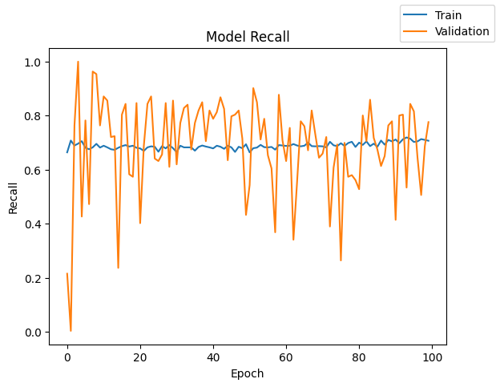

```python
plot(history0,'recall')
```

```python
model_0_train_perf = model_performance_classification(model0, X_train, y_train)
model_0_train_perf
```

|  | Accuracy | Recall | Precision | F1 Score |
| --- | --- | --- | --- | --- |
| 0 | 0.683906 | 0.683906 | 0.810899 | 0.714237 |

```python
model_0_valid_perf = model_performance_classification(model0, X_valid, y_valid)
model_0_valid_perf
```

|  | Accuracy | Recall | Precision | F1 Score |
| --- | --- | --- | --- | --- |
| 0 | 0.684375 | 0.684375 | 0.807978 | 0.714532 |

- Low F1 score AND recall

```python
#Predicting the results using 0.5 as the threshold - if not done, confusion matrix gives error
y_train_pred = model0.predict(X_train)
y_train_pred = (y_train_pred > 0.5)
y_train_pred
```

```
array([[ True],
       [False],
       [False],
       ...,
       [False],
       [ True],
       [False]])
```

```python
#Predicting the results using 0.5 as the threshold
y_val_pred = model0.predict(X_valid)
y_val_pred = (y_val_pred > 0.5)
y_val_pred
```

```
array([[ True],
       [False],
       [False],
       ...,
       [False],
       [ True],
       [ True]])
```

```python
#classification report on train set
cr=classification_report(y_train, y_train_pred)
print(cr)
```

```
              precision    recall  f1-score   support

         0.0       0.92      0.66      0.77      5096
         1.0       0.37      0.79      0.50      1304

    accuracy                           0.68      6400
   macro avg       0.65      0.72      0.64      6400
weighted avg       0.81      0.68      0.71      6400
```

```python
#classification report on validation set
cr=classification_report(y_valid, y_val_pred)
print(cr)
```

```
              precision    recall  f1-score   support

         0.0       0.92      0.66      0.77      1274
         1.0       0.37      0.78      0.50       326

    accuracy                           0.68      1600
   macro avg       0.64      0.72      0.63      1600
weighted avg       0.81      0.68      0.71      1600
```

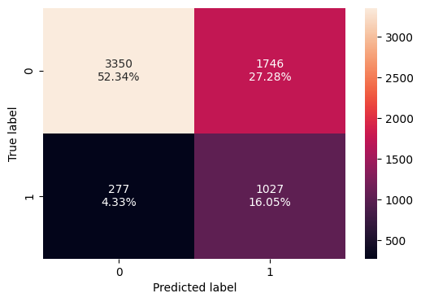

```python
#Calculating the confusion matrix on train
make_confusion_matrix(y_train, y_train_pred)
```

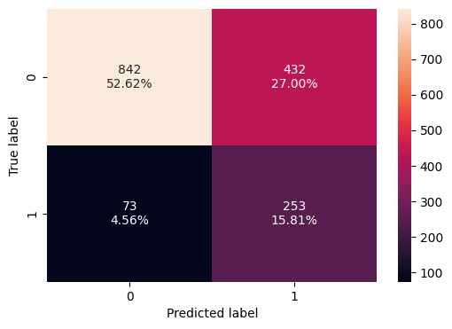

```python
#confusion matrix on val
make_confusion_matrix(y_valid, y_val_pred)
```

## Model Performance Improvement

### Model1 - Neural Network with Adam Optimizer

```python
#introduce momentum as well as an adaptive learning rate
# clears the current Keras session, resetting all layers and models previously created, freeing up memory and resources.
tf.keras.backend.clear_session()
np.random.seed(1)
tf.random.set_seed(1)
random.seed(1)
#Initializing the neural network
model1 = Sequential()
model1.add(Dense(64,activation="relu",input_dim=X_train.shape[1]))
model1.add(Dense(32,activation="relu"))
model1.add(Dense(16,activation="relu"))
model1.add(Dense(1,activation="sigmoid"))
```

```python
model1.summary()
```

```
Model: "sequential"
_________________________________________________________________
 Layer (type)                Output Shape              Param #
=================================================================
 dense (Dense)               (None, 64)                768

 dense_1 (Dense)             (None, 32)                2080

 dense_2 (Dense)             (None, 16)                528

 dense_3 (Dense)             (None, 1)                 17

=================================================================
Total params: 3393 (13.25 KB)
Trainable params: 3393 (13.25 KB)
Non-trainable params: 0 (0.00 Byte)
_________________________________________________________________
```

```python
optimizer1 = tf.keras.optimizers.Adam()    # defining Adam as the optimizer to be used
# function for f1 score

model1.compile(loss='binary_crossentropy', optimizer=optimizer1 , metrics=[AUC(curve='ROC'), Recall()])
start = time.time()
history1 = model1.fit(X_train, y_train, validation_data=(X_valid,y_valid) , batch_size=batch_size, epochs=epochs,class_weight=cw_dict, verbose=1)
end=time.time()
```

```python
print("Time taken in seconds ",end-start)
```

```
Time taken in seconds  42.126830101013184
```

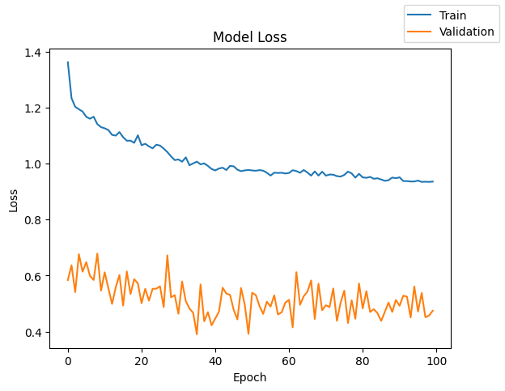

```python
plot(history1,'loss')
```

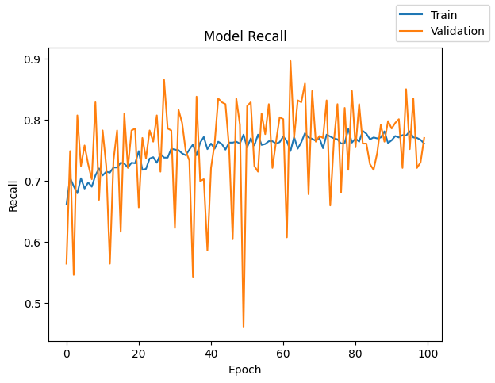

```python
plot(history1,'recall')
```

```python
model_1_train_perf = model_performance_classification(model1, X_train, y_train)
model_1_train_perf
```

|  | Accuracy | Recall | Precision | F1 Score |
| --- | --- | --- | --- | --- |
| 0 | 0.76875 | 0.76875 | 0.838232 | 0.787616 |

```python
model_1_valid_perf = model_performance_classification(model1, X_valid, y_valid)
model_1_valid_perf
```

|  | Accuracy | Recall | Precision | F1 Score |
| --- | --- | --- | --- | --- |
| 0 | 0.77125 | 0.77125 | 0.834162 | 0.789118 |

```
              precision    recall  f1-score   support

         0.0       0.93      0.76      0.84      5096
         1.0       0.46      0.79      0.58      1304

    accuracy                           0.77      6400
   macro avg       0.70      0.78      0.71      6400
weighted avg       0.84      0.77      0.79      6400

              precision    recall  f1-score   support

         0.0       0.93      0.77      0.84      1274
         1.0       0.46      0.77      0.58       326

    accuracy                           0.77      1600
   macro avg       0.70      0.77      0.71      1600
weighted avg       0.83      0.77      0.79      1600
```

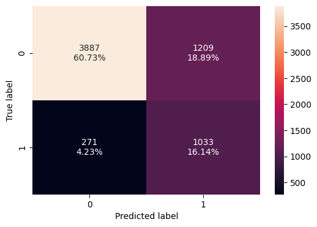

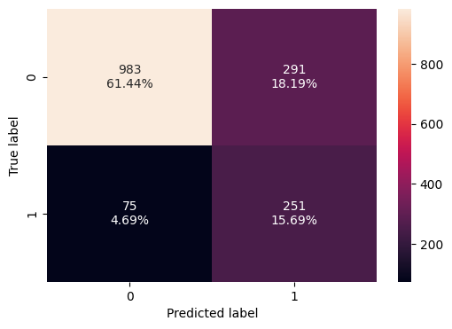

```python
#Predicting the results using 0.5 as the threshold - if not done, confusion matrix gives error
y_train_pred = model1.predict(X_train)
y_train_pred = (y_train_pred > 0.5)
y_train_pred

#Predicting the results using 0.5 as the threshold
y_val_pred = model1.predict(X_valid)
y_val_pred = (y_val_pred > 0.5)
y_val_pred


#classification report on train set
cr=classification_report(y_train, y_train_pred)
print(cr)

#classification report on validation set
cr=classification_report(y_valid, y_val_pred)
print(cr)

#Calculating the confusion matrix on train
make_confusion_matrix(y_train, y_train_pred)

#confusion matrix on val
make_confusion_matrix(y_valid, y_val_pred)
```

### Model2 - Neural Network with Adam Optimizer and Dropout

```python
# clears the current Keras session, resetting all layers and models previously created, freeing up memory and resources.
tf.keras.backend.clear_session()
np.random.seed(1)
tf.random.set_seed(1)
random.seed(1)
#Initializing the neural network
model2 = Sequential()
model2.add(Dense(64,activation="relu",input_dim=X_train.shape[1]))
#adding dropput
model2.add(Dropout(0.4))
model2.add(Dense(32,activation="relu"))
model2.add(Dropout(0.2))
model2.add(Dense(16,activation="relu"))
model2.add(Dense(1,activation="sigmoid"))

model2.summary()
```

```
Model: "sequential"
_________________________________________________________________
 Layer (type)                Output Shape              Param #
=================================================================
 dense (Dense)               (None, 64)                768

 dropout (Dropout)           (None, 64)                0

 dense_1 (Dense)             (None, 32)                2080

 dropout_1 (Dropout)         (None, 32)                0

 dense_2 (Dense)             (None, 16)                528

 dense_3 (Dense)             (None, 1)                 17

=================================================================
Total params: 3393 (13.25 KB)
Trainable params: 3393 (13.25 KB)
Non-trainable params: 0 (0.00 Byte)
_________________________________________________________________
```

```python
optimizer = tf.keras.optimizers.Adam()    # defining Adam as the optimizer to be used
model2.compile(loss='binary_crossentropy', optimizer=optimizer, metrics=[AUC(curve='ROC'), Recall()])

start = time.time()
history2 = model2.fit(X_train, y_train, validation_data=(X_valid,y_valid) , batch_size=batch_size, epochs=epochs,class_weight=cw_dict)
end=time.time()
```

```
Time taken in seconds  42.79570245742798
```

|  | Accuracy | Recall | Precision | F1 Score |
| --- | --- | --- | --- | --- |
| 0 | 0.775625 | 0.775625 | 0.835102 | 0.79274 |

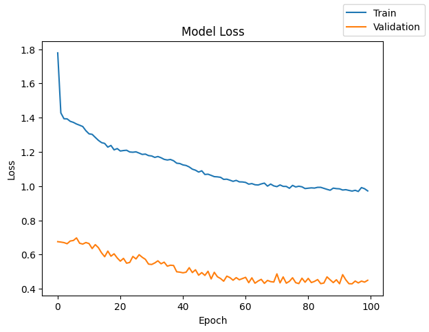

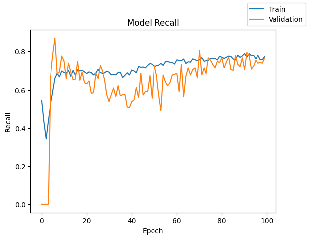

```python
print("Time taken in seconds ",end-start)
#Plotting Train Loss vs Validation Loss
plot(history2,'loss')

plot(history2,'recall')
model_2_train_perf = model_performance_classification(model2, X_train, y_train)
model_2_train_perf

model_2_valid_perf = model_performance_classification(model2, X_valid, y_valid)
model_2_valid_perf
```

```
              precision    recall  f1-score   support

         0.0       0.93      0.78      0.85      5096
         1.0       0.47      0.75      0.58      1304

    accuracy                           0.78      6400
   macro avg       0.70      0.77      0.71      6400
weighted avg       0.83      0.78      0.79      6400

              precision    recall  f1-score   support

         0.0       0.93      0.78      0.85      1274
         1.0       0.47      0.77      0.58       326

    accuracy                           0.78      1600
   macro avg       0.70      0.77      0.71      1600
weighted avg       0.84      0.78      0.79      1600
```

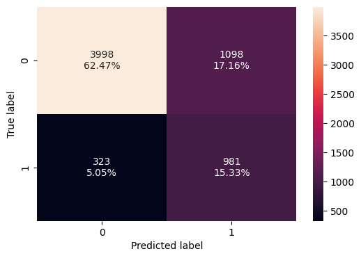

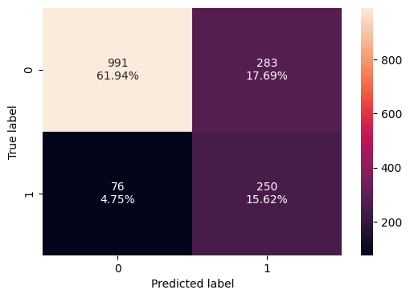

```python
#Predicting the results using 0.5 as the threshold - if not done, confusion matrix gives error
y_train_pred = model2.predict(X_train)
y_train_pred = (y_train_pred > 0.5)
y_train_pred

#Predicting the results using 0.5 as the threshold
y_val_pred = model2.predict(X_valid)
y_val_pred = (y_val_pred > 0.5)
y_val_pred


#classification report on train set
cr=classification_report(y_train, y_train_pred)
print(cr)

#classification report on validation set
cr=classification_report(y_valid, y_val_pred)
print(cr)

#Calculating the confusion matrix on train
make_confusion_matrix(y_train, y_train_pred)

#confusion matrix on val
make_confusion_matrix(y_valid, y_val_pred)
```